# First assignment: The Class

February 10, 2016

# Introduction

The first exploratory project in the Exploratory Data Analysis and Visualization focuses on the survey response dataset, acquired through the online questionnaire about statistical and technical literacy distributed among the students of EDAV class.

We want to analyze the characteristics of EDAV students in terms of 3 overall dimensions:

- Knowledge of tools
- Confidence in skills
- Preference of text editor

The data we will be working with for this assignment consists of survey responses from **114** graduate students, which are enrolled in one of the following programs:

- IDSE
- Data Science Certificate
- Statistics
- Others (include QMSS, Applied Math, Biomedical Informatics etc.)

## Cleaning the data

In order to work with clean and consistent data, we created a function called ‘tinydata’ that takes the *xlsx* file containing the raw responses and returns a consistent data frame used across all the analyses performed.

Tidy data transformations are stored as a script file named `tidydata.R` in our working directory that is sourced and run before we start the analysis.

In a nutshell, tidydata does the following:

1. Removes the columns that have no observations in them.
2. Regroups the columns in a logical manner.
3. Organizes the factor levels in the following columns
   1. Waiting List Info
   2. Gender
   3. Program
   4. Text Editors
4. Splits the “Experience with Tools”" column to multiple columns with a 1/0 value depending on if the skill was reported or not. Splitting the variable makes it tidy.

The codebook for tidy dataset is provided in the project main directory (`codebook.txt`), one can refer to it regarding the information each variable, its possible values, levels etc.

The distribution of respondents by program and gender is as follows:

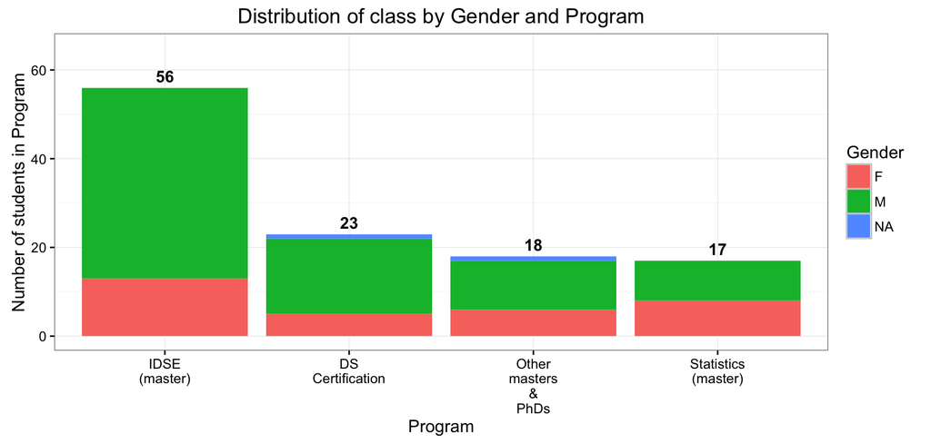

```r
#the source code for each plot can be found in /src/ folder in main project directory
source("src/tidydata.R")
source("src/GenderProgramPlot.R")
filename <- "raw/Survey+Response.xlsx"
df <- tidydata(filename)
GenderProgramPlot(df)
```

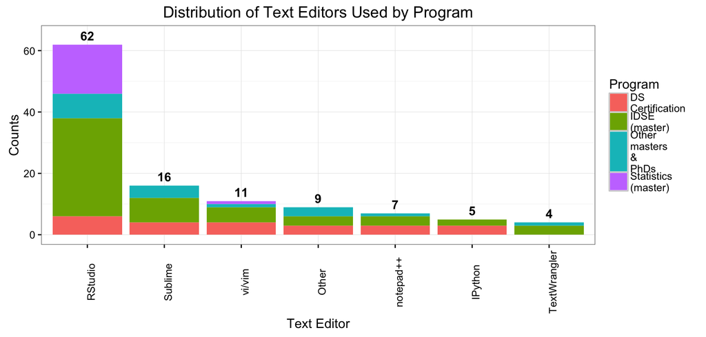

Another set of interesting facts can be revealed from the distribution of preferred text and code editors across the programs presented on the course. As the majority of students come from data science and statistics programs, it is quite expected that the leading code editor named in the survey is RStudio, which is the leading IDE for R development. RStudio is followed Sublime, which is one of the most widespread and very universal code editors in the market right now, and surprisingly the third place is taken by vi/vim, which is a quite sophisticated command line text editing tool, which indicates that the course accommodates significant portion of students with vast programming background, besides the overal programming literacy on the course is sustainably high. Unpredictably few people selected IPython as their preferred text editor, though it is considered as a really convenient interactive tool for Python development, which is also extremely widespread for statistical calculations.

We continue our analysis by exploring different toolkits that students from different programs pick to be using.

## Tools

As we learned in the previous chapter, the respondents come from very diverse backgrounds and, as such, have learned and been exposed to very different sets of tools.

There is a list of 16 tools, and each student was asked which of these he or she was comfortable using. As we can see in the following plot, “IDSE” and “Others” tend to know more tools on average